# ISYE 6414 Project Modelling

```r
library(ggplot2)
library(dplyr)
library(stats)
library(car)
```

```r
data = read.csv("Life-Expectancy-Data-Updated.csv")
data_filtered  = data[, c("BMI", "GDP_per_capita", "Schooling", "Region", "Economy_status_Developed", "Life_expectancy","Infant_deaths","Adult_mortality")]
head(data_filtered)
```

|  | BMI | GDP_per_capita | Schooling | Region | Economy_status_Developed | Life_expectancy | Infant_deaths | Adult_mortality |
| --- | --- | --- | --- | --- | --- | --- | --- | --- |
| 1 | 27.8 | 11006 | 7.8 | Middle East | 0 | 76.5 | 11.1 | 105.8240 |
| 2 | 26.0 | 25742 | 9.7 | European Union | 1 | 82.8 | 2.7 | 57.9025 |
| 3 | 21.2 | 1076 | 5.0 | Asia | 0 | 65.4 | 51.5 | 201.0765 |
| 4 | 25.3 | 4146 | 7.9 | South America | 0 | 67.0 | 32.8 | 222.1965 |
| 5 | 27.0 | 33995 | 12.8 | Middle East | 1 | 81.7 | 3.4 | 57.9510 |
| 6 | 26.4 | 9110 | 7.9 | Central America and Caribbean | 0 | 78.2 | 9.8 | 95.2200 |

We have read the data and only considered the follwing columns - “BMI”, “GDP_per_capita”, “Schooling”, “Region”, “Economy_status_Developed”,“Life_expectancy”,“Infant_deaths”,“Adult_mortality”, This is in order to simplify the analysis -(we have removed variables which have low correlation with the target variable and those which have correlated with other predictor variables)

```r
data_filtered$Region <- factor(data_filtered$Region)
```

```r
set.seed(123)  # Set seed for reproducibility
total_rows <- nrow(data_filtered)
test_percentage <- 10
test_size <- round((test_percentage / 100) * total_rows)
test_indices <- sample(1:total_rows, test_size)
test_data <- data_filtered[test_indices, ]
train_data <- data_filtered[-test_indices, ]
```

Taking 90:10 split of Training and Validation data sets

```r
min <- lm(Life_expectancy ~ 1, train_data)
full <- lm(Life_expectancy ~ ., train_data)
model=step(min, scope = list(lower = min, upper =
full),direction = "forward")
```

```
Start:  AIC=11522.39
Life_expectancy ~ 1

                           Df Sum of Sq    RSS     AIC
+ Adult_mortality           1    201410  23510  5702.4
+ Infant_deaths             1    191000  33921  6647.5
+ Region                    8    139681  85239  9037.0
+ Schooling                 1    121422 103498  9523.4
+ BMI                       1     80981 143939 10373.7
+ GDP_per_capita            1     76001 148919 10461.4
+ Economy_status_Developed  1     61017 163903 10708.5
<none>                                  224920 11522.4

Step:  AIC=5702.4
Life_expectancy ~ Adult_mortality

                           Df Sum of Sq     RSS    AIC
+ Infant_deaths             1   16963.2  6546.5 2408.5
+ Schooling                 1   11053.4 12456.2 4066.9
+ Region                    8    7163.1 16346.5 4781.6
+ Economy_status_Developed  1    3678.2 19831.4 5265.8
+ BMI                       1    3236.0 20273.7 5322.6
+ GDP_per_capita            1    2891.8 20617.9 5366.0
<none>                                  23509.7 5702.4

Step:  AIC=2408.48
Life_expectancy ~ Adult_mortality + Infant_deaths

                           Df Sum of Sq    RSS    AIC
+ Region                    8   1195.58 5350.9 1904.6
+ Economy_status_Developed  1    912.91 5633.6 2023.3
+ GDP_per_capita            1    828.06 5718.4 2061.8
+ Schooling                 1    690.21 5856.3 2123.2
+ BMI                       1     25.68 6520.8 2400.3
<none>                                  6546.5 2408.5

Step:  AIC=1904.6
Life_expectancy ~ Adult_mortality + Infant_deaths + Region

                           Df Sum of Sq    RSS    AIC
```

[output cut: 21 more lines]

```
+ Schooling  1    80.038 4073.5 1207.4
<none>                   4153.5 1255.6
+ BMI        1     0.003 4153.5 1257.6

Step:  AIC=1207.39
Life_expectancy ~ Adult_mortality + Infant_deaths + Region +
    Economy_status_Developed + GDP_per_capita + Schooling

       Df Sum of Sq    RSS    AIC
+ BMI   1    19.013 4054.5 1197.3
<none>              4073.5 1207.4

Step:  AIC=1197.33
Life_expectancy ~ Adult_mortality + Infant_deaths + Region +
    Economy_status_Developed + GDP_per_capita + Schooling + BMI
```

```r
summary(model)
```

```
Call:
lm(formula = Life_expectancy ~ Adult_mortality + Infant_deaths +
    Region + Economy_status_Developed + GDP_per_capita + Schooling +
    BMI, data = train_data)

Residuals:
    Min      1Q  Median      3Q     Max
-3.8995 -0.8510  0.0222  0.8803  4.1535

Coefficients:
                                      Estimate Std. Error  t value Pr(>|t|)
(Intercept)                          8.144e+01  5.034e-01  161.772  < 2e-16 ***
Adult_mortality                     -4.597e-02  4.145e-04 -110.908  < 2e-16 ***
Infant_deaths                       -1.306e-01  2.101e-03  -62.135  < 2e-16 ***
RegionAsia                           5.808e-01  1.010e-01    5.749 1.01e-08 ***
RegionCentral America and Caribbean  1.942e+00  1.099e-01   17.668  < 2e-16 ***
RegionEuropean Union                -6.775e-01  1.686e-01   -4.019 6.01e-05 ***
RegionMiddle East                    1.725e-01  1.275e-01    1.352 0.176414
RegionNorth America                  7.276e-01  2.213e-01    3.288 0.001022 **
RegionOceania                       -6.669e-01  1.355e-01   -4.922 9.09e-07 ***
RegionRest of Europe                 1.747e-01  1.299e-01    1.346 0.178546
RegionSouth America                  1.719e+00  1.264e-01   13.601  < 2e-16 ***
Economy_status_Developed             2.242e+00  1.616e-01   13.871  < 2e-16 ***
GDP_per_capita                       1.751e-05  2.293e-06    7.637 3.13e-14 ***
Schooling                            1.359e-01  1.717e-02    7.913 3.71e-15 ***
BMI                                 -7.168e-02  2.068e-02   -3.467 0.000535 ***
---
Signif. codes:  0 ‘***’ 0.001 ‘**’ 0.01 ‘*’ 0.05 ‘.’ 0.1 ‘ ’ 1

Residual standard error: 1.258 on 2563 degrees of freedom
Multiple R-squared:  0.982, Adjusted R-squared:  0.9819
F-statistic:  9973 on 14 and 2563 DF,  p-value: < 2.2e-16
```

Forwards Stepwise regression gives the following predictor variables - “BMI”, “GDP_per_capita”, “Schooling”, “Region”, “Economy_status_Developed”, “Infant_deaths”,“Adult_mortality”

```r
model=step(full,scope = list(lower = min, upper = full),
direction = "backward")
```

```
Start:  AIC=1197.33
Life_expectancy ~ BMI + GDP_per_capita + Schooling + Region +
    Economy_status_Developed + Infant_deaths + Adult_mortality

                           Df Sum of Sq     RSS    AIC
<none>                                   4054.5 1197.3
- BMI                       1      19.0  4073.5 1207.4
- GDP_per_capita            1      92.3  4146.7 1253.3
- Schooling                 1      99.0  4153.5 1257.6
- Economy_status_Developed  1     304.4  4358.8 1381.9
- Region                    8    1162.4  5216.8 1831.2
- Infant_deaths             1    6107.5 10161.9 3564.1
- Adult_mortality           1   19458.6 23513.1 5726.8
```

```r
summary(model)
```

```
Call:
lm(formula = Life_expectancy ~ BMI + GDP_per_capita + Schooling +
    Region + Economy_status_Developed + Infant_deaths + Adult_mortality,
    data = train_data)

Residuals:
    Min      1Q  Median      3Q     Max
-3.8995 -0.8510  0.0222  0.8803  4.1535

Coefficients:
                                      Estimate Std. Error  t value Pr(>|t|)
(Intercept)                          8.144e+01  5.034e-01  161.772  < 2e-16 ***
BMI                                 -7.168e-02  2.068e-02   -3.467 0.000535 ***
GDP_per_capita                       1.751e-05  2.293e-06    7.637 3.13e-14 ***
Schooling                            1.359e-01  1.717e-02    7.913 3.71e-15 ***
RegionAsia                           5.808e-01  1.010e-01    5.749 1.01e-08 ***
RegionCentral America and Caribbean  1.942e+00  1.099e-01   17.668  < 2e-16 ***
RegionEuropean Union                -6.775e-01  1.686e-01   -4.019 6.01e-05 ***
RegionMiddle East                    1.725e-01  1.275e-01    1.352 0.176414
RegionNorth America                  7.276e-01  2.213e-01    3.288 0.001022 **
RegionOceania                       -6.669e-01  1.355e-01   -4.922 9.09e-07 ***
RegionRest of Europe                 1.747e-01  1.299e-01    1.346 0.178546
RegionSouth America                  1.719e+00  1.264e-01   13.601  < 2e-16 ***
Economy_status_Developed             2.242e+00  1.616e-01   13.871  < 2e-16 ***
Infant_deaths                       -1.306e-01  2.101e-03  -62.135  < 2e-16 ***
Adult_mortality                     -4.597e-02  4.145e-04 -110.908  < 2e-16 ***
---
Signif. codes:  0 ‘***’ 0.001 ‘**’ 0.01 ‘*’ 0.05 ‘.’ 0.1 ‘ ’ 1

Residual standard error: 1.258 on 2563 degrees of freedom
Multiple R-squared:  0.982, Adjusted R-squared:  0.9819
F-statistic:  9973 on 14 and 2563 DF,  p-value: < 2.2e-16
```

Backward Stepwise regression also gives us the same predictor variables

```r
model_final = lm(formula = Life_expectancy ~ BMI + GDP_per_capita + Schooling +
    Region + Economy_status_Developed + Infant_deaths + Adult_mortality, data = train_data)
summary(model_final)
```

```
Call:
lm(formula = Life_expectancy ~ BMI + GDP_per_capita + Schooling +
    Region + Economy_status_Developed + Infant_deaths + Adult_mortality,
    data = train_data)

Residuals:
    Min      1Q  Median      3Q     Max
-3.8995 -0.8510  0.0222  0.8803  4.1535

Coefficients:
                                      Estimate Std. Error  t value Pr(>|t|)
(Intercept)                          8.144e+01  5.034e-01  161.772  < 2e-16 ***
BMI                                 -7.168e-02  2.068e-02   -3.467 0.000535 ***
GDP_per_capita                       1.751e-05  2.293e-06    7.637 3.13e-14 ***
Schooling                            1.359e-01  1.717e-02    7.913 3.71e-15 ***
RegionAsia                           5.808e-01  1.010e-01    5.749 1.01e-08 ***
RegionCentral America and Caribbean  1.942e+00  1.099e-01   17.668  < 2e-16 ***
RegionEuropean Union                -6.775e-01  1.686e-01   -4.019 6.01e-05 ***
RegionMiddle East                    1.725e-01  1.275e-01    1.352 0.176414
RegionNorth America                  7.276e-01  2.213e-01    3.288 0.001022 **
RegionOceania                       -6.669e-01  1.355e-01   -4.922 9.09e-07 ***
RegionRest of Europe                 1.747e-01  1.299e-01    1.346 0.178546
RegionSouth America                  1.719e+00  1.264e-01   13.601  < 2e-16 ***
Economy_status_Developed             2.242e+00  1.616e-01   13.871  < 2e-16 ***
Infant_deaths                       -1.306e-01  2.101e-03  -62.135  < 2e-16 ***
Adult_mortality                     -4.597e-02  4.145e-04 -110.908  < 2e-16 ***
---
Signif. codes:  0 ‘***’ 0.001 ‘**’ 0.01 ‘*’ 0.05 ‘.’ 0.1 ‘ ’ 1

Residual standard error: 1.258 on 2563 degrees of freedom
Multiple R-squared:  0.982, Adjusted R-squared:  0.9819
F-statistic:  9973 on 14 and 2563 DF,  p-value: < 2.2e-16
```

All the predictor values are significant with a pvalue threshold of 0.01, however Regions in Rest of Europe and Middle East are not significant predictors since their pvalue >0.01

```r
residual <- residuals(model_final)
mean(residual)
```

```
[1] 5.383161e-17
```

Mean of residuals are very close to zero, which is concurrent with the assumptions

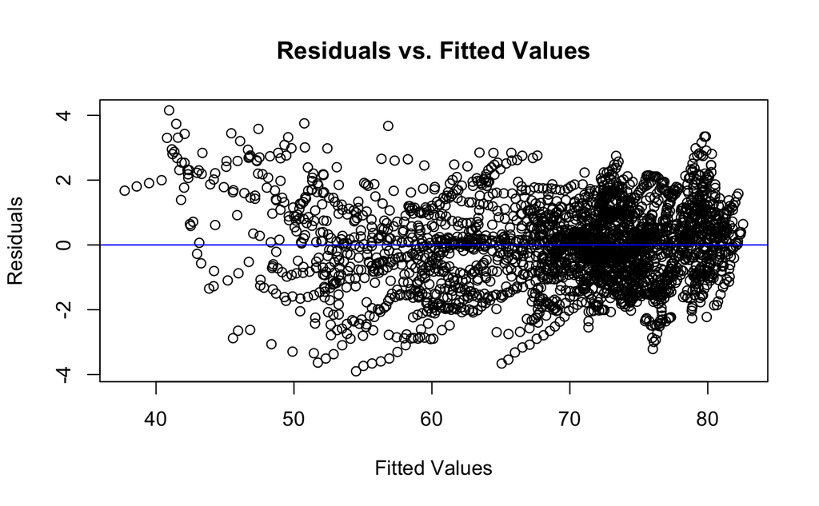

```r
plot(fitted(model_final), resid(model_final), main = "Residuals vs. Fitted Values", xlab = "Fitted Values", ylab = "Residuals")
abline(h = 0, col = "blue")
```

The Residuals vs fitted plot does not have any patterns confirming linearity and the variance also does not change significantly as we move along the x-axis, thus confirming constant variance assumption.

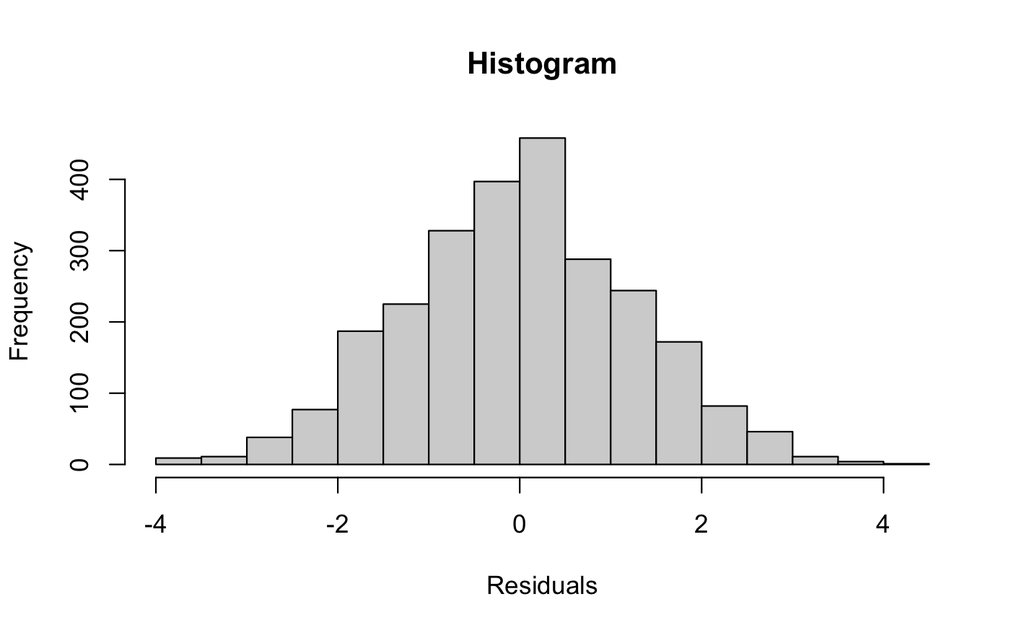

```r
hist(residual, main = "Histogram", xlab = "Residuals")
```

```
148 384
141 352
```

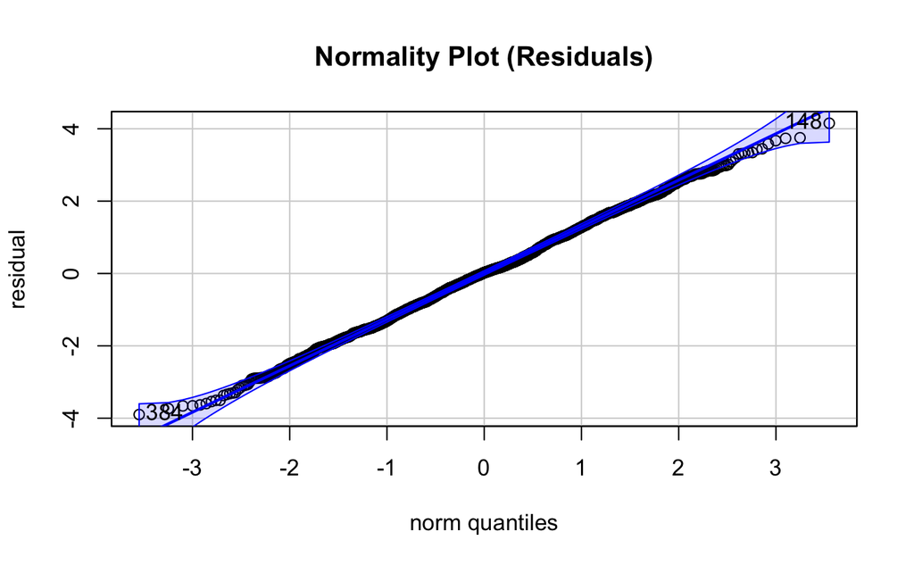

```r
qqPlot(residual, main = "Normality Plot (Residuals)")
```

The Histogram is approximately symmetrical with one peak and no gaps in between confirming normality, also the QQ plot follows the 45 degree line as well which strengthens the assumption of normality.

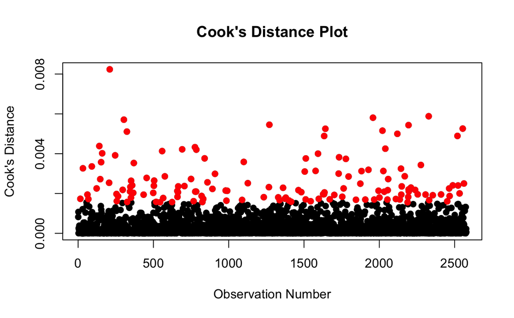

```r
cooksd <- cooks.distance(model_final)

threshold <- 4/length(cooksd)

# Identify outliers based on the threshold
outliers <- which(cooksd > threshold)

# Plot Cook's distance values against observation numbers
plot(cooksd, pch = 19, main = "Cook's Distance Plot", ylab = "Cook's Distance", xlab = "Observation Number")

# Highlight outliers with a different color
points(outliers, cooksd[outliers], pch = 19, col = "red")
```

```r
# Print the list of outlier indices
cat("Outlier Indices:", outliers, "\n")
```

```
Outlier Indices: 32 62 68 91 123 141 147 153 156 160 206 210 246 248 255 265 294 296 304 324 345 347 351 352 353 359 366 370 435 455 499 503 505 508 518 544 558 568 576 624 659 660 663 665 691 706 750 767 776 778 784 785 820 825 840 859 892 909 980 985 990 1068 1089 1100 1127 1233 1267 1270 1296 132…
```

```r
cat("Number of Outliers:", length(outliers))
```

```
Number of Outliers: 147
```

There are 147 outliers from the Cooks Distance Plot using a threshold of 4/n

```r
outlier_table = train_data[outliers,]
table(outlier_table$Region)
```

[output not shown]

```r
train_data$IsOutlier <- ifelse(1:nrow(train_data) %in% outliers, "Outlier", "Non-Outlier")

# Calculate the mean of GDP_per_capita for outliers and non-outliers
mean_gdp_outliers <- mean(train_data$GDP_per_capita[train_data$IsOutlier == "Outlier"], na.rm = TRUE)
mean_gdp_non_outliers <- mean(train_data$GDP_per_capita[train_data$IsOutlier == "Non-Outlier"], na.rm = TRUE)

# Print the results
cat("Mean GDP_per_capita for Outliers:", mean_gdp_outliers, "\n")
```

```
Mean GDP_per_capita for Outliers: 5732.916
```

```r
cat("Mean GDP_per_capita for Non-Outliers:", mean_gdp_non_outliers, "\n")
```

```
Mean GDP_per_capita for Non-Outliers: 11895.85
```

however these datapoints do not highly deviate from the data and might be influential data points to the analysis. We can see that most of these datapoints are from African regions where the life expectancy is generally lower than other regions, also looking at the GDP we can see that the Mean GDP_per_capita is much higher for Non-Outliers compared to outliers, thus we can understand that outliers are capturing the life expectancy of underdeveloped countires and if we remove them, this may lead to a bias in the result. Thus we do not remove outliers.

```r
print("VIF:")
```

```
[1] "VIF:"
```

```r
vif(model_final)
```

```
                              GVIF Df GVIF^(1/(2*Df))
BMI                       3.332021  1        1.825382
GDP_per_capita            2.453452  1        1.566350
Schooling                 4.799696  1        2.190821
Region                   20.715834  8        1.208562
Economy_status_Developed  7.001472  1        2.646029
Infant_deaths             5.420006  1        2.328091
Adult_mortality           3.612277  1        1.900599
```

```r
cat("VIF threshold is :", max(10,1/(1-summary(model_final)$r.squared)))
```

```
VIF threshold is : 55.4746
```

Since VIF < VIF threshold = max(10,1/(1-R^2)) = 55.47 - no multicollinearity exists

```r
predictions_train <- predict(model_final, newdata = train_data)

# Evaluate model performance
mse <- mean((train_data$Life_expectancy - predictions_train)^2)
r_squared <- cor(train_data$Life_expectancy, predictions_train)^2

# Print evaluation metrics
cat("Mean Squared Error (MSE) Training:", mse, "\n")
```

```
Mean Squared Error (MSE) Training: 1.572719
```

```r
cat("R-squared Training:", r_squared, "\n")
```

```
R-squared Training: 0.9819737
```

```r
predictions_test <- predict(model_final, newdata = test_data)

# Evaluate model performance
mse <- mean((test_data$Life_expectancy - predictions_test)^2)
r_squared <- cor(test_data$Life_expectancy, predictions_test)^2

# Print evaluation metrics
cat("Mean Squared Error (MSE) Testing:", mse, "\n")
```

```
Mean Squared Error (MSE) Testing: 1.663451
```

```r
cat("R-squared Testing:", r_squared, "\n")
```

```
R-squared Testing: 0.9831172
```

The model is performing well on the test dataset as well with low Testing MSE and high R^2